# Wrangling & Visualization

### Qualify 6.

### Define: Change underscore to space for p1,p2, and p3

```python
img_df_clean['p1'] = img_df_clean['p1'].str.replace('_', ' ')
img_df_clean['p2'] = img_df_clean['p2'].str.replace('_', ' ')
img_df_clean['p3'] = img_df_clean['p3'].str.replace('_', ' ')
```

```python
#test
img_df_clean.head(5)
```

|  | tweet_id | jpg_url | img_num | p1 | p1_conf | p1_dog | p2 | p2_conf | p2_dog | p3 | p3_conf | p3_dog |
| --- | --- | --- | --- | --- | --- | --- | --- | --- | --- | --- | --- | --- |
| 0 | 666020888022790149 | https://pbs.twimg.com/media/CT4udn0WwAA0aMy.jpg | 1 | welsh springer spaniel | 0.465074 | True | collie | 0.156665 | True | shetland sheepdog | 0.061428 | True |
| 1 | 666029285002620928 | https://pbs.twimg.com/media/CT42GRgUYAA5iDo.jpg | 1 | redbone | 0.506826 | True | miniature pinscher | 0.074192 | True | rhodesian ridgeback | 0.072010 | True |
| 2 | 666033412701032449 | https://pbs.twimg.com/media/CT4521TWwAEvMyu.jpg | 1 | german shepherd | 0.596461 | True | malinois | 0.138584 | True | bloodhound | 0.116197 | True |
| 3 | 666044226329800704 | https://pbs.twimg.com/media/CT5Dr8HUEAA-lEu.jpg | 1 | rhodesian ridgeback | 0.408143 | True | redbone | 0.360687 | True | miniature pinscher | 0.222752 | True |
| 4 | 666049248165822465 | https://pbs.twimg.com/media/CT5IQmsXIAAKY4A.jpg | 1 | miniature pinscher | 0.560311 | True | rottweiler | 0.243682 | True | doberman | 0.154629 | True |

### Qualify 7

### Define: Change the 'id' to 'tweet_id'

```python
# using rename function changing column name from id to tweet_id
api_data_clean.rename({'id': 'tweet_id'}, axis=1, inplace=True)
```

```python
#test
api_data_clean.columns
```

```
Index(['tweet_id', 'retweet_count', 'favorite_count', 'followers_count'], dtype='object')
```

### Qualify 8

### Tweet_id(s) of arc_df table are missing in img_df table

Keep only those records in arc_df table whose tweet_id exists in img_df table

```python
arc_df_clean = arc_df_clean[arc_df_clean.tweet_id.isin(img_df.tweet_id)]
```

```python
#test
len(arc_df_clean[~arc_df_clean.tweet_id.isin(img_df.tweet_id)])
```

```
0
```

### Define: Merge the data from api_data with the arc_df table

```python
arc_df_clean = pd.merge(left=arc_df_clean, right=api_data_clean, how='left', on='tweet_id')
```

```python
arc_df_clean.head()
```

|  | tweet_id | timestamp | source | text | expanded_urls | rating_numerator | rating_denominator | name | doggo | floofer | pupper | puppo | retweet_count_x | favorite_count_x | followers_count_x | date | time | retweet_count_y | favorite_count_y | followers_count_y |
| --- | --- | --- | --- | --- | --- | --- | --- | --- | --- | --- | --- | --- | --- | --- | --- | --- | --- | --- | --- | --- |
| 0 | 892420643555336193 | 2017-08-01 16:23:56+00:00 | <a href="http://twitter.com/download/iphone" r... | This is Phineas. He's a mystical boy. Only eve... | https://twitter.com/dog_rates/status/892420643... | 13 | 10 | Phineas | NaN | NaN | NaN | NaN | 8033.0 | 37355.0 | 8222802.0 | 08-01-2017 | 16:23 | 8033.0 | 37355.0 | 8222802.0 |
| 1 | 892177421306343426 | 2017-08-01 00:17:27+00:00 | <a href="http://twitter.com/download/iphone" r... | This is Tilly. She's just checking pup on you.... | https://twitter.com/dog_rates/status/892177421... | 13 | 10 | Tilly | NaN | NaN | NaN | NaN | 5963.0 | 32108.0 | 8222802.0 | 08-01-2017 | 00:17 | 5963.0 | 32108.0 | 8222802.0 |
| 2 | 891815181378084864 | 2017-07-31 00:18:03+00:00 | <a href="http://twitter.com/download/iphone" r... | This is Archie. He is a rare Norwegian Pouncin... | https://twitter.com/dog_rates/status/891815181... | 12 | 10 | Archie | NaN | NaN | NaN | NaN | 3944.0 | 24213.0 | 8222802.0 | 07-31-2017 | 00:18 | 3944.0 | 24213.0 | 8222802.0 |
| 3 | 891689557279858688 | 2017-07-30 15:58:51+00:00 | <a href="http://twitter.com/download/iphone" r... | This is Darla. She commenced a snooze mid meal... | https://twitter.com/dog_rates/status/891689557... | 13 | 10 | Darla | NaN | NaN | NaN | NaN | 8185.0 | 40653.0 | 8222802.0 | 07-30-2017 | 15:58 | 8185.0 | 40653.0 | 8222802.0 |
| 4 | 891327558926688256 | 2017-07-29 16:00:24+00:00 | <a href="http://twitter.com/download/iphone" r... | This is Franklin. He would like you to stop ca... | https://twitter.com/dog_rates/status/891327558... | 12 | 10 | Franklin | NaN | NaN | NaN | NaN | 8875.0 | 38876.0 | 8222802.0 | 07-29-2017 | 16:00 | 8875.0 | 38876.0 | 8222802.0 |

```python
arc_df_clean.info()
```

[output not shown]

### Define: drop empty retweeted_status_id, retweeted_status_user_id, and retweeted_status_timestamp.

```python
arc_df_clean.drop(['retweeted_status_id', 'retweeted_status_user_id', 'retweeted_status_timestamp'], axis=1, inplace=True)
```

```python
arc_df_clean.info()
```

[output not shown]

### Define : Convert the datatype from string to categorical.

```python
arc_df_clean.source = arc_df_clean.source.str.replace(r'<(?:a\b[^>]*>|/a>)', '')
```

```python
arc_df_clean.source = arc_df_clean.source.astype('category')
```

```python
arc_df_clean.source.value_counts()
```

```
Twitter for iPhone    1955
Twitter Web Client      28
TweetDeck               11
Name: source, dtype: int64
```

### Define: Drop the redundant columns in the arc_df table

```python
arc_df_clean['dog_type'] = arc_df_clean.puppo.fillna(arc_df_clean.pupper.fillna(arc_df_clean.floofer.fillna(arc_df_clean.doggo)))
```

```python
arc_df_clean.drop(['doggo', 'floofer', 'pupper', 'puppo'], axis=1, inplace=True)
```

```python
# Test
arc_df_clean.dog_type.head(10)
```

```
0      NaN
1      NaN
2      NaN
3      NaN
4      NaN
5      NaN
6      NaN
7      NaN
8      NaN
9    doggo
Name: dog_type, dtype: object
```

```python
arc_df_clean.dog_type.value_counts()
```

```
pupper     229
doggo       66
puppo       28
floofer      3
Name: dog_type, dtype: int64
```

The original number for pupper was 272, doggo 98, floofer 4, and puppo 37.

```python
arc_df_clean.columns
```

```
Index(['tweet_id', 'timestamp', 'source', 'text', 'expanded_urls',
       'rating_numerator', 'rating_denominator', 'name', 'retweet_count_x',
       'favorite_count_x', 'followers_count_x', 'date', 'time',
       'retweet_count_y', 'favorite_count_y', 'followers_count_y', 'dog_type'],
      dtype='object')
```

### Define: Change to date time format

```python
arc_df_clean['date'] = pd.to_datetime(arc_df_clean['date'])
arc_df_clean['time'] = pd.to_datetime(arc_df_clean['time'])
```

```python
#Test
type(arc_df_clean['date'].iloc[0])
type(arc_df_clean['time'].iloc[0])
```

```
pandas._libs.tslibs.timestamps.Timestamp
```

### Define: Merge df_clean, image_clean and twitter_clean dataframes.

```python
arc_df_master = pd.merge(arc_df_clean, img_df_clean, on ='tweet_id', how= 'inner' )
arc_df_master = pd.merge(arc_df_master, api_data_clean, on = 'tweet_id', how = 'inner' )
```

```python
#Test
arc_df_master.info()
```

```
<class 'pandas.core.frame.DataFrame'>
Int64Index: 1923 entries, 0 to 1922
Data columns (total 31 columns):
tweet_id              1923 non-null int64
timestamp             1923 non-null datetime64[ns, UTC]
source                1923 non-null category
text                  1923 non-null object
expanded_urls         1923 non-null object
rating_numerator      1923 non-null int64
rating_denominator    1923 non-null int64
name                  1318 non-null object
retweet_count_x       1923 non-null float64
favorite_count_x      1923 non-null float64
followers_count_x     1923 non-null float64
date                  1923 non-null datetime64[ns]
time                  1923 non-null datetime64[ns]
retweet_count_y       1923 non-null float64
favorite_count_y      1923 non-null float64
followers_count_y     1923 non-null float64
dog_type              316 non-null object
jpg_url               1923 non-null object
img_num               1923 non-null int64
p1                    1923 non-null object
p1_conf               1923 non-null float64
p1_dog                1923 non-null bool
p2                    1923 non-null object
p2_conf               1923 non-null float64
p2_dog                1923 non-null bool
p3                    1923 non-null object
p3_conf               1923 non-null float64
p3_dog                1923 non-null bool
retweet_count         1923 non-null int64
favorite_count        1923 non-null int64
followers_count       1923 non-null int64
dtypes: bool(3), category(1), datetime64[ns, UTC](1), datetime64[ns](2), float64(9), int64(7), object(8)
memory usage: 428.3+ KB
```

### Img_ df_clean

```python
img_df_clean
```

|  | tweet_id | jpg_url | img_num | p1 | p1_conf | p1_dog | p2 | p2_conf | p2_dog | p3 | p3_conf | p3_dog |
| --- | --- | --- | --- | --- | --- | --- | --- | --- | --- | --- | --- | --- |
| 0 | 666020888022790149 | https://pbs.twimg.com/media/CT4udn0WwAA0aMy.jpg | 1 | welsh springer spaniel | 0.465074 | True | collie | 0.156665 | True | shetland sheepdog | 0.061428 | True |
| 1 | 666029285002620928 | https://pbs.twimg.com/media/CT42GRgUYAA5iDo.jpg | 1 | redbone | 0.506826 | True | miniature pinscher | 0.074192 | True | rhodesian ridgeback | 0.072010 | True |
| 2 | 666033412701032449 | https://pbs.twimg.com/media/CT4521TWwAEvMyu.jpg | 1 | german shepherd | 0.596461 | True | malinois | 0.138584 | True | bloodhound | 0.116197 | True |
| 3 | 666044226329800704 | https://pbs.twimg.com/media/CT5Dr8HUEAA-lEu.jpg | 1 | rhodesian ridgeback | 0.408143 | True | redbone | 0.360687 | True | miniature pinscher | 0.222752 | True |
| 4 | 666049248165822465 | https://pbs.twimg.com/media/CT5IQmsXIAAKY4A.jpg | 1 | miniature pinscher | 0.560311 | True | rottweiler | 0.243682 | True | doberman | 0.154629 | True |
| 5 | 666050758794694657 | https://pbs.twimg.com/media/CT5Jof1WUAEuVxN.jpg | 1 | bernese mountain dog | 0.651137 | True | english springer | 0.263788 | True | greater swiss mountain dog | 0.016199 | True |
| 6 | 666051853826850816 | https://pbs.twimg.com/media/CT5KoJ1WoAAJash.jpg | 1 | box turtle | 0.933012 | False | mud turtle | 0.045885 | False | terrapin | 0.017885 | False |
| 7 | 666055525042405380 | https://pbs.twimg.com/media/CT5N9tpXIAAifs1.jpg | 1 | chow | 0.692517 | True | tibetan mastiff | 0.058279 | True | fur coat | 0.054449 | False |
| 8 | 666057090499244032 | https://pbs.twimg.com/media/CT5PY90WoAAQGLo.jpg | 1 | shopping cart | 0.962465 | False | shopping basket | 0.014594 | False | golden retriever | 0.007959 | True |
| 9 | 666058600524156928 | https://pbs.twimg.com/media/CT5Qw94XAAA_2dP.jpg | 1 | miniature poodle | 0.201493 | True | komondor | 0.192305 | True | soft-coated wheaten terrier | 0.082086 | True |
| 10 | 666063827256086533 | https://pbs.twimg.com/media/CT5Vg_wXIAAXfnj.jpg | 1 | golden retriever | 0.775930 | True | tibetan mastiff | 0.093718 | True | labrador retriever | 0.072427 | True |
| 11 | 666071193221509120 | https://pbs.twimg.com/media/CT5cN_3WEAAlOoZ.jpg | 1 | gordon setter | 0.503672 | True | yorkshire terrier | 0.174201 | True | pekinese | 0.109454 | True |
| 12 | 666073100786774016 | https://pbs.twimg.com/media/CT5d9DZXAAALcwe.jpg | 1 | walker hound | 0.260857 | True | english foxhound | 0.175382 | True | ibizan hound | 0.097471 | True |
| 13 | 666082916733198337 | https://pbs.twimg.com/media/CT5m4VGWEAAtKc8.jpg | 1 | pug | 0.489814 | True | bull mastiff | 0.404722 | True | french bulldog | 0.048960 | True |
| 14 | 666094000022159362 | https://pbs.twimg.com/media/CT5w9gUW4AAsBNN.jpg | 1 | bloodhound | 0.195217 | True | german shepherd | 0.078260 | True | malinois | 0.075628 | True |
| 15 | 666099513787052032 | https://pbs.twimg.com/media/CT51-JJUEAA6hV8.jpg | 1 | lhasa | 0.582330 | True | shih-tzu | 0.166192 | True | dandie dinmont | 0.089688 | True |
| 16 | 666102155909144576 | https://pbs.twimg.com/media/CT54YGiWUAEZnoK.jpg | 1 | english setter | 0.298617 | True | newfoundland | 0.149842 | True | borzoi | 0.133649 | True |
| 17 | 666104133288665088 | https://pbs.twimg.com/media/CT56LSZWoAAlJj2.jpg | 1 | hen | 0.965932 | False | cock | 0.033919 | False | partridge | 0.000052 | False |
| 18 | 666268910803644416 | https://pbs.twimg.com/media/CT8QCd1WEAADXws.jpg | 1 | desktop computer | 0.086502 | False | desk | 0.085547 | False | bookcase | 0.079480 | False |
| 19 | 666273097616637952 | https://pbs.twimg.com/media/CT8T1mtUwAA3aqm.jpg | 1 | italian greyhound | 0.176053 | True | toy terrier | 0.111884 | True | basenji | 0.111152 | True |
| 20 | 666287406224695296 | https://pbs.twimg.com/media/CT8g3BpUEAAuFjg.jpg | 1 | maltese dog | 0.857531 | True | toy poodle | 0.063064 | True | miniature poodle | 0.025581 | True |
| 21 | 666293911632134144 | https://pbs.twimg.com/media/CT8mx7KW4AEQu8N.jpg | 1 | three-toed sloth | 0.914671 | False | otter | 0.015250 | False | great grey owl | 0.013207 | False |
| 22 | 666337882303524864 | https://pbs.twimg.com/media/CT9OwFIWEAMuRje.jpg | 1 | ox | 0.416669 | False | newfoundland | 0.278407 | True | groenendael | 0.102643 | True |
| 23 | 666345417576210432 | https://pbs.twimg.com/media/CT9Vn7PWoAA_ZCM.jpg | 1 | golden retriever | 0.858744 | True | chesapeake bay retriever | 0.054787 | True | labrador retriever | 0.014241 | True |
| 24 | 666353288456101888 | https://pbs.twimg.com/media/CT9cx0tUEAAhNN_.jpg | 1 | malamute | 0.336874 | True | siberian husky | 0.147655 | True | eskimo dog | 0.093412 | True |
| 25 | 666362758909284353 | https://pbs.twimg.com/media/CT9lXGsUcAAyUFt.jpg | 1 | guinea pig | 0.996496 | False | skunk | 0.002402 | False | hamster | 0.000461 | False |
| 26 | 666373753744588802 | https://pbs.twimg.com/media/CT9vZEYWUAAlZ05.jpg | 1 | soft-coated wheaten terrier | 0.326467 | True | afghan hound | 0.259551 | True | briard | 0.206803 | True |
| 27 | 666396247373291520 | https://pbs.twimg.com/media/CT-D2ZHWIAA3gK1.jpg | 1 | chihuahua | 0.978108 | True | toy terrier | 0.009397 | True | papillon | 0.004577 | True |
| 28 | 666407126856765440 | https://pbs.twimg.com/media/CT-NvwmW4AAugGZ.jpg | 1 | black-and-tan coonhound | 0.529139 | True | bloodhound | 0.244220 | True | flat-coated retriever | 0.173810 | True |
| 29 | 666411507551481857 | https://pbs.twimg.com/media/CT-RugiWIAELEaq.jpg | 1 | coho | 0.404640 | False | barracouta | 0.271485 | False | gar | 0.189945 | False |
| ... | ... | ... | ... | ... | ... | ... | ... | ... | ... | ... | ... | ... |
| 2044 | 886258384151887873 | https://pbs.twimg.com/media/DEyfTG4UMAE4aE9.jpg | 1 | pug | 0.943575 | True | shower cap | 0.025286 | False | siamese cat | 0.002849 | False |
| 2045 | 886366144734445568 | https://pbs.twimg.com/media/DE0BTnQUwAApKEH.jpg | 1 | french bulldog | 0.999201 | True | chihuahua | 0.000361 | True | boston bull | 0.000076 | True |
| 2046 | 886680336477933568 | https://pbs.twimg.com/media/DE4fEDzWAAAyHMM.jpg | 1 | convertible | 0.738995 | False | sports car | 0.139952 | False | car wheel | 0.044173 | False |
| 2047 | 886736880519319552 | https://pbs.twimg.com/media/DE5Se8FXcAAJFx4.jpg | 1 | kuvasz | 0.309706 | True | great pyrenees | 0.186136 | True | dandie dinmont | 0.086346 | True |
| 2048 | 886983233522544640 | https://pbs.twimg.com/media/DE8yicJW0AAAvBJ.jpg | 2 | chihuahua | 0.793469 | True | toy terrier | 0.143528 | True | can opener | 0.032253 | False |
| 2049 | 887101392804085760 | https://pbs.twimg.com/media/DE-eAq6UwAA-jaE.jpg | 1 | samoyed | 0.733942 | True | eskimo dog | 0.035029 | True | staffordshire bullterrier | 0.029705 | True |
| 2050 | 887343217045368832 | https://pbs.twimg.com/ext_tw_video_thumb/88734... | 1 | mexican hairless | 0.330741 | True | sea lion | 0.275645 | False | weimaraner | 0.134203 | True |
| 2052 | 887517139158093824 | https://pbs.twimg.com/ext_tw_video_thumb/88751... | 1 | limousine | 0.130432 | False | tow truck | 0.029175 | False | shopping cart | 0.026321 | False |
| 2053 | 887705289381826560 | https://pbs.twimg.com/media/DFHDQBbXgAEqY7t.jpg | 1 | basset | 0.821664 | True | redbone | 0.087582 | True | weimaraner | 0.026236 | True |
| 2054 | 888078434458587136 | https://pbs.twimg.com/media/DFMWn56WsAAkA7B.jpg | 1 | french bulldog | 0.995026 | True | pug | 0.000932 | True | bull mastiff | 0.000903 | True |
| 2055 | 888202515573088257 | https://pbs.twimg.com/media/DFDw2tyUQAAAFke.jpg | 2 | pembroke | 0.809197 | True | rhodesian ridgeback | 0.054950 | True | beagle | 0.038915 | True |
| 2056 | 888554962724278272 | https://pbs.twimg.com/media/DFTH_O-UQAACu20.jpg | 3 | siberian husky | 0.700377 | True | eskimo dog | 0.166511 | True | malamute | 0.111411 | True |
| 2057 | 888804989199671297 | https://pbs.twimg.com/media/DFWra-3VYAA2piG.jpg | 1 | golden retriever | 0.469760 | True | labrador retriever | 0.184172 | True | english setter | 0.073482 | True |
| 2058 | 888917238123831296 | https://pbs.twimg.com/media/DFYRgsOUQAARGhO.jpg | 1 | golden retriever | 0.714719 | True | tibetan mastiff | 0.120184 | True | labrador retriever | 0.105506 | True |
| 2059 | 889278841981685760 | https://pbs.twimg.com/ext_tw_video_thumb/88927... | 1 | whippet | 0.626152 | True | borzoi | 0.194742 | True | saluki | 0.027351 | True |
| 2060 | 889531135344209921 | https://pbs.twimg.com/media/DFg_2PVW0AEHN3p.jpg | 1 | golden retriever | 0.953442 | True | labrador retriever | 0.013834 | True | redbone | 0.007958 | True |
| 2061 | 889638837579907072 | https://pbs.twimg.com/media/DFihzFfXsAYGDPR.jpg | 1 | french bulldog | 0.991650 | True | boxer | 0.002129 | True | staffordshire bullterrier | 0.001498 | True |
| 2062 | 889665388333682689 | https://pbs.twimg.com/media/DFi579UWsAAatzw.jpg | 1 | pembroke | 0.966327 | True | cardigan | 0.027356 | True | basenji | 0.004633 | True |
| 2063 | 889880896479866881 | https://pbs.twimg.com/media/DFl99B1WsAITKsg.jpg | 1 | french bulldog | 0.377417 | True | labrador retriever | 0.151317 | True | muzzle | 0.082981 | False |
| 2064 | 890006608113172480 | https://pbs.twimg.com/media/DFnwSY4WAAAMliS.jpg | 1 | samoyed | 0.957979 | True | pomeranian | 0.013884 | True | chow | 0.008167 | True |
| 2065 | 890240255349198849 | https://pbs.twimg.com/media/DFrEyVuW0AAO3t9.jpg | 1 | pembroke | 0.511319 | True | cardigan | 0.451038 | True | chihuahua | 0.029248 | True |
| 2066 | 890609185150312448 | https://pbs.twimg.com/media/DFwUU__XcAEpyXI.jpg | 1 | irish terrier | 0.487574 | True | irish setter | 0.193054 | True | chesapeake bay retriever | 0.118184 | True |
| 2067 | 890729181411237888 | https://pbs.twimg.com/media/DFyBahAVwAAhUTd.jpg | 2 | pomeranian | 0.566142 | True | eskimo dog | 0.178406 | True | pembroke | 0.076507 | True |
| 2068 | 890971913173991426 | https://pbs.twimg.com/media/DF1eOmZXUAALUcq.jpg | 1 | appenzeller | 0.341703 | True | border collie | 0.199287 | True | ice lolly | 0.193548 | False |
| 2069 | 891087950875897856 | https://pbs.twimg.com/media/DF3HwyEWsAABqE6.jpg | 1 | chesapeake bay retriever | 0.425595 | True | irish terrier | 0.116317 | True | indian elephant | 0.076902 | False |
| 2070 | 891327558926688256 | https://pbs.twimg.com/media/DF6hr6BUMAAzZgT.jpg | 2 | basset | 0.555712 | True | english springer | 0.225770 | True | german short-haired pointer | 0.175219 | True |
| 2071 | 891689557279858688 | https://pbs.twimg.com/media/DF_q7IAWsAEuuN8.jpg | 1 | paper towel | 0.170278 | False | labrador retriever | 0.168086 | True | spatula | 0.040836 | False |
| 2072 | 891815181378084864 | https://pbs.twimg.com/media/DGBdLU1WsAANxJ9.jpg | 1 | chihuahua | 0.716012 | True | malamute | 0.078253 | True | kelpie | 0.031379 | True |
| 2073 | 892177421306343426 | https://pbs.twimg.com/media/DGGmoV4XsAAUL6n.jpg | 1 | chihuahua | 0.323581 | True | pekinese | 0.090647 | True | papillon | 0.068957 | True |
| 2074 | 892420643555336193 | https://pbs.twimg.com/media/DGKD1-bXoAAIAUK.jpg | 1 | orange | 0.097049 | False | bagel | 0.085851 | False | banana | 0.076110 | False |

2009 rows × 12 columns

```python
img_df_clean.info()
```

```
<class 'pandas.core.frame.DataFrame'>
Int64Index: 2009 entries, 0 to 2074
Data columns (total 12 columns):
tweet_id    2009 non-null int64
jpg_url     2009 non-null object
img_num     2009 non-null int64
p1          2009 non-null object
p1_conf     2009 non-null float64
p1_dog      2009 non-null bool
p2          2009 non-null object
p2_conf     2009 non-null float64
p2_dog      2009 non-null bool
p3          2009 non-null object
p3_conf     2009 non-null float64
p3_dog      2009 non-null bool
dtypes: bool(3), float64(3), int64(2), object(4)
memory usage: 162.8+ KB
```

```python
sum(img_df_clean.jpg_url.duplicated())
```

```
0
```

```python
img_df_clean.p1.value_counts()
img_df_clean.p2.value_counts()
img_df_clean.p3.value_counts()
```

```
labrador retriever                76
chihuahua                         57
golden retriever                  46
eskimo dog                        36
kelpie                            33
kuvasz                            31
chow                              31
beagle                            30
staffordshire bullterrier         30
cocker spaniel                    29
toy poodle                        29
pekinese                          29
pomeranian                        27
great pyrenees                    26
pembroke                          26
french bulldog                    25
malamute                          25
chesapeake bay retriever          24
american staffordshire terrier    23
cardigan                          23
pug                               21
bull mastiff                      20
basenji                           20
siberian husky                    19
toy terrier                       18
shetland sheepdog                 17
boston bull                       17
lakeland terrier                  16
boxer                             16
dingo                             15
                                  ..
soccer ball                        1
spatula                            1
oxcart                             1
padlock                            1
conch                              1
tiger cat                          1
banana                             1
canoe                              1
shovel                             1
chimpanzee                         1
rotisserie                         1
hammerhead                         1
maze                               1
acorn                              1
plunger                            1
jersey                             1
screw                              1
whiptail                           1
cowboy boot                        1
shower cap                         1
shoji                              1
jeep                               1
pajama                             1
mitten                             1
loggerhead                         1
maraca                             1
lion                               1
pretzel                            1
nipple                             1
rifle                              1
Name: p3, Length: 408, dtype: int64
```

```python
img_df_clean.describe()
```

|  | tweet_id | img_num | p1_conf | p2_conf | p3_conf |
| --- | --- | --- | --- | --- | --- |
| count | 2.009000e+03 | 2009.000000 | 2009.000000 | 2.009000e+03 | 2.009000e+03 |
| mean | 7.377256e+17 | 1.202588 | 0.594467 | 1.340727e-01 | 6.017061e-02 |
| std | 6.812757e+16 | 0.559483 | 0.272236 | 1.006394e-01 | 5.085369e-02 |
| min | 6.660209e+17 | 1.000000 | 0.044333 | 1.011300e-08 | 1.740170e-10 |
| 25% | 6.761463e+17 | 1.000000 | 0.362925 | 5.353130e-02 | 1.610520e-02 |
| 50% | 7.101532e+17 | 1.000000 | 0.588230 | 1.170030e-01 | 4.947150e-02 |
| 75% | 7.931657e+17 | 1.000000 | 0.847292 | 1.948970e-01 | 9.157150e-02 |
| max | 8.924206e+17 | 4.000000 | 1.000000 | 4.880140e-01 | 2.734190e-01 |

### api_data_clean

```python
api_data_clean
```

|  | tweet_id | retweet_count | favorite_count | followers_count |
| --- | --- | --- | --- | --- |
| 0 | 892420643555336193 | 8033 | 37355 | 8222802 |
| 1 | 892177421306343426 | 5963 | 32108 | 8222802 |
| 2 | 891815181378084864 | 3944 | 24213 | 8222802 |
| 3 | 891689557279858688 | 8185 | 40653 | 8222802 |
| 4 | 891327558926688256 | 8875 | 38876 | 8222802 |
| 5 | 891087950875897856 | 2951 | 19546 | 8222802 |
| 6 | 890971913173991426 | 1951 | 11412 | 8222803 |
| 7 | 890729181411237888 | 17903 | 62959 | 8222803 |
| 8 | 890609185150312448 | 4054 | 26880 | 8222803 |
| 9 | 890240255349198849 | 6984 | 30811 | 8222803 |
| 10 | 890006608113172480 | 6949 | 29623 | 8222803 |
| 11 | 889880896479866881 | 4728 | 26880 | 8222803 |
| 12 | 889665388333682689 | 9511 | 46441 | 8222803 |
| 13 | 889638837579907072 | 4274 | 26158 | 8222803 |
| 14 | 889531135344209921 | 2139 | 14603 | 8222803 |
| 15 | 889278841981685760 | 5088 | 24361 | 8222803 |
| 16 | 888917238123831296 | 4261 | 28128 | 8222803 |
| 17 | 888804989199671297 | 4040 | 24691 | 8222803 |
| 18 | 888554962724278272 | 3339 | 19127 | 8222803 |
| 19 | 888078434458587136 | 3296 | 21014 | 8222803 |
| 20 | 887705289381826560 | 5108 | 29137 | 8222803 |
| 21 | 887517139158093824 | 11119 | 44709 | 8222803 |
| 22 | 887473957103951883 | 17146 | 66482 | 8222803 |
| 23 | 887343217045368832 | 9897 | 32496 | 8222802 |
| 24 | 887101392804085760 | 5659 | 29524 | 8222802 |
| 25 | 886983233522544640 | 7305 | 33870 | 8222802 |
| 26 | 886736880519319552 | 3076 | 11598 | 8222802 |
| 27 | 886680336477933568 | 4225 | 21655 | 8222802 |
| 28 | 886366144734445568 | 3023 | 20427 | 8222802 |
| 29 | 886267009285017600 | 4 | 116 | 8222802 |
| ... | ... | ... | ... | ... |
| 2304 | 666411507551481857 | 316 | 425 | 8222991 |
| 2305 | 666407126856765440 | 37 | 103 | 8222991 |
| 2306 | 666396247373291520 | 80 | 160 | 8222992 |
| 2307 | 666373753744588802 | 86 | 179 | 8222992 |
| 2308 | 666362758909284353 | 543 | 749 | 8222992 |
| 2309 | 666353288456101888 | 71 | 211 | 8222383 |
| 2310 | 666345417576210432 | 130 | 282 | 8222992 |
| 2311 | 666337882303524864 | 87 | 189 | 8222992 |
| 2312 | 666293911632134144 | 336 | 482 | 8222992 |
| 2313 | 666287406224695296 | 63 | 141 | 8222993 |
| 2314 | 666273097616637952 | 75 | 166 | 8222993 |
| 2315 | 666268910803644416 | 32 | 99 | 8222993 |
| 2316 | 666104133288665088 | 6225 | 13857 | 8222993 |
| 2317 | 666102155909144576 | 11 | 75 | 8222993 |
| 2318 | 666099513787052032 | 63 | 147 | 8222993 |
| 2319 | 666094000022159362 | 69 | 158 | 8222993 |
| 2320 | 666082916733198337 | 42 | 109 | 8222993 |
| 2321 | 666073100786774016 | 152 | 310 | 8222993 |
| 2322 | 666071193221509120 | 55 | 140 | 8222993 |
| 2323 | 666063827256086533 | 205 | 457 | 8222993 |
| 2324 | 666058600524156928 | 56 | 108 | 8222993 |
| 2325 | 666057090499244032 | 132 | 281 | 8222993 |
| 2326 | 666055525042405380 | 228 | 421 | 8222993 |
| 2327 | 666051853826850816 | 811 | 1177 | 8222993 |
| 2328 | 666050758794694657 | 56 | 129 | 8222994 |
| 2329 | 666049248165822465 | 41 | 103 | 8222994 |
| 2330 | 666044226329800704 | 135 | 286 | 8222995 |
| 2331 | 666033412701032449 | 43 | 121 | 8222996 |
| 2332 | 666029285002620928 | 46 | 125 | 8222996 |
| 2333 | 666020888022790149 | 486 | 2491 | 8222996 |

2334 rows × 4 columns

```python
api_data_clean.info()
```

```
<class 'pandas.core.frame.DataFrame'>
RangeIndex: 2334 entries, 0 to 2333
Data columns (total 4 columns):
tweet_id           2334 non-null int64
retweet_count      2334 non-null int64
favorite_count     2334 non-null int64
followers_count    2334 non-null int64
dtypes: int64(4)
memory usage: 73.0 KB
```

```python
api_data_clean.describe()
```

|  | tweet_id | retweet_count | favorite_count | followers_count |
| --- | --- | --- | --- | --- |
| count | 2.334000e+03 | 2334.000000 | 2334.000000 | 2.334000e+03 |
| mean | 7.419439e+17 | 2822.670523 | 7784.230077 | 8.222869e+06 |
| std | 6.819580e+16 | 4776.867089 | 12079.513943 | 7.460236e+01 |
| min | 6.660209e+17 | 1.000000 | 0.000000 | 8.222189e+06 |
| 25% | 6.782926e+17 | 567.000000 | 1352.000000 | 8.222821e+06 |
| 50% | 7.184574e+17 | 1320.500000 | 3389.500000 | 8.222864e+06 |
| 75% | 7.986600e+17 | 3294.000000 | 9555.500000 | 8.222914e+06 |
| max | 8.924206e+17 | 81088.000000 | 161314.000000 | 8.222996e+06 |

### Define: doggo, floofer, pupper and puppo columns in arc_df table should be merged into one column named "stage"

```python
arc_df_clean.puppo.value_counts()
```

[output not shown]

```python
arc_df_clean['stage'] = arc_df_clean[['doggo', 'floofer', 'pupper', 'puppo']].max(axis=1)
```

### Define: Values for rating_denominator are incorrect

```python
# regex to match fractions
pattern = "\s*(\d+([.]\d+)?([/]\d+))"

# function which will match the above pattern and return an array of fractions, if any
def tokens(x):
  return [m.group(1) for m in re.finditer(pattern, x)]
```

```python
# iterate through all those records whose rating_denominator is not 10
for i, row in arc_df_clean[arc_df_clean.rating_denominator != 10].iterrows():
    d = row.rating_denominator

    # if rating_denominator is greater than 10 and divisible by 10
    if d > 10 and d%10 == 0:
        # assign divisor as the quotient
        divisor = d/10
        n = row.rating_numerator

        # if rating_numerator is greater than 10 and divisible by the divisor
        if n%divisor == 0:
            # reassign rating_denominator as 10
            arc_df_clean.set_value(i, 'rating_denominator', 10)
            # reassign rating_numerator as the quotient of rating_numerator by divisor
            arc_df_clean.set_value(i, 'rating_numerator', int(n/divisor))

    # for all those records whose rating_denominator is either less than 10 or not divisible by 10
    else:
        # extract all fractions(ratings) from text using tokens function
        ratings = tokens(row.text)
        # iterate through all the fractions
        for rating in ratings:
            # if denominator of any such fraction is equal to 10
            if rating.split('/')[1] == '10':
                # reassign rating_denominator as 10
                arc_df_clean.set_value(i, 'rating_denominator', 10)
                # reassign rating_numerator as the numerator value of this fraction
                arc_df_clean.set_value(i, 'rating_numerator', int(round(float(rating.split('/')[0]))))
                break
```

```python
#Test
arc_df_clean.rating_denominator.value_counts()
```

```
10.0    1976
40.0       2
60.0       1
70.0       1
50.0       1
Name: rating_denominator, dtype: int64
```

### Define: Multiple columns containing the same type of data in the predictions table

```python
# Change column names
col_names = ['tweet_id', 'jpg_url', 'img_num',
             'prediction_1', 'confidence_1', 'dog_1',
             'prediction_2', 'confidence_2', 'dog_2',
             'prediction_3', 'confidence_3', 'dog_3']
img_df_clean.columns = col_names
```

```python
# Convert wide to long
img_df_clean = pd.wide_to_long(img_df_clean,
                                    stubnames=['prediction', 'confidence', 'dog'],
                      i=['tweet_id', 'jpg_url', 'img_num'], j='prediction_order', sep='_')\
.reset_index()
```

```python
#test
# Visual inspection
img_df_clean.head(9)
```

|  | tweet_id | jpg_url | img_num | prediction_order | prediction | confidence | dog |
| --- | --- | --- | --- | --- | --- | --- | --- |
| 0 | 666020888022790149 | https://pbs.twimg.com/media/CT4udn0WwAA0aMy.jpg | 1 | 1 | welsh springer spaniel | 0.465074 | True |
| 1 | 666020888022790149 | https://pbs.twimg.com/media/CT4udn0WwAA0aMy.jpg | 1 | 2 | collie | 0.156665 | True |
| 2 | 666020888022790149 | https://pbs.twimg.com/media/CT4udn0WwAA0aMy.jpg | 1 | 3 | shetland sheepdog | 0.061428 | True |
| 3 | 666029285002620928 | https://pbs.twimg.com/media/CT42GRgUYAA5iDo.jpg | 1 | 1 | redbone | 0.506826 | True |
| 4 | 666029285002620928 | https://pbs.twimg.com/media/CT42GRgUYAA5iDo.jpg | 1 | 2 | miniature pinscher | 0.074192 | True |
| 5 | 666029285002620928 | https://pbs.twimg.com/media/CT42GRgUYAA5iDo.jpg | 1 | 3 | rhodesian ridgeback | 0.072010 | True |
| 6 | 666033412701032449 | https://pbs.twimg.com/media/CT4521TWwAEvMyu.jpg | 1 | 1 | german shepherd | 0.596461 | True |
| 7 | 666033412701032449 | https://pbs.twimg.com/media/CT4521TWwAEvMyu.jpg | 1 | 2 | malinois | 0.138584 | True |
| 8 | 666033412701032449 | https://pbs.twimg.com/media/CT4521TWwAEvMyu.jpg | 1 | 3 | bloodhound | 0.116197 | True |

### Define

#### archive_clean table:

-tweet_id: change to str -timestamp: change to datetime -dog_type: categorical

#### predictions_clean table:

-tweet_id: change to str -prediction_order: changet to categorical

```python
arc_df_clean.tweet_id = arc_df_clean.tweet_id.astype(str)
img_df_clean.tweet_id = img_df_clean.tweet_id.astype(str)
```

```python
arc_df_clean.timestamp = pd.to_datetime(arc_df_clean.timestamp)
```

```python
arc_df_clean.dog_type = arc_df_clean.dog_type.astype("category")
img_df_clean.prediction_order = img_df_clean.prediction_order.astype("category")
```

```python
#test
arc_df_clean.info()
```

```
<class 'pandas.core.frame.DataFrame'>
Int64Index: 1994 entries, 0 to 1993
Data columns (total 17 columns):
tweet_id              1994 non-null object
timestamp             1994 non-null datetime64[ns, UTC]
source                1994 non-null category
text                  1994 non-null object
expanded_urls         1994 non-null object
rating_numerator      1994 non-null int64
rating_denominator    1981 non-null float64
name                  1372 non-null object
retweet_count_x       1988 non-null float64
favorite_count_x      1988 non-null float64
followers_count_x     1988 non-null float64
date                  1994 non-null datetime64[ns]
time                  1994 non-null datetime64[ns]
retweet_count_y       1988 non-null float64
favorite_count_y      1988 non-null float64
followers_count_y     1988 non-null float64
dog_type              326 non-null category
dtypes: category(2), datetime64[ns, UTC](1), datetime64[ns](2), float64(7), int64(1), object(4)
memory usage: 333.4+ KB
```

```python
img_df_clean.info()
```

```
<class 'pandas.core.frame.DataFrame'>
RangeIndex: 6027 entries, 0 to 6026
Data columns (total 7 columns):
tweet_id            6027 non-null object
jpg_url             6027 non-null object
img_num             6027 non-null int64
prediction_order    6027 non-null category
prediction          6027 non-null object
confidence          6027 non-null float64
dog                 6027 non-null bool
dtypes: bool(1), category(1), float64(1), int64(1), object(3)
memory usage: 247.4+ KB
```

### Storing Data

```python
arc_df_clean.to_csv('twitter_arc_df_master.csv', encoding='utf-8', index=False)
img_df_clean.to_csv('image_predictions.tsv', index = False)
```

### Analyzing Data

```python
arc_df = pd.read_csv('twitter_arc_df_master.csv')
img_df = pd.read_csv('image_predictions.tsv')
```

```python
arc_df.info()
```

```
<class 'pandas.core.frame.DataFrame'>
RangeIndex: 1994 entries, 0 to 1993
Data columns (total 17 columns):
tweet_id              1994 non-null int64
timestamp             1994 non-null object
source                1994 non-null object
text                  1994 non-null object
expanded_urls         1994 non-null object
rating_numerator      1994 non-null int64
rating_denominator    1981 non-null float64
name                  1372 non-null object
retweet_count_x       1988 non-null float64
favorite_count_x      1988 non-null float64
followers_count_x     1988 non-null float64
date                  1994 non-null object
time                  1994 non-null object
retweet_count_y       1988 non-null float64
favorite_count_y      1988 non-null float64
followers_count_y     1988 non-null float64
dog_type              326 non-null object
dtypes: float64(7), int64(2), object(8)
memory usage: 264.9+ KB
```

```python
img_df.info()
```

```
<class 'pandas.core.frame.DataFrame'>
RangeIndex: 6027 entries, 0 to 6026
Data columns (total 7 columns):
tweet_id            6027 non-null int64
jpg_url             6027 non-null object
img_num             6027 non-null int64
prediction_order    6027 non-null int64
prediction          6027 non-null object
confidence          6027 non-null float64
dog                 6027 non-null bool
dtypes: bool(1), float64(1), int64(3), object(2)
memory usage: 288.5+ KB
```

```python
arc_df.tweet_id = arc_df.tweet_id.astype(str)
img_df.tweet_id = img_df.tweet_id.astype(str)
arc_df.dog_type = arc_df.dog_type.astype("category")
img_df.prediction_order = img_df.prediction_order.astype("category")
arc_df.timestamp = pd.to_datetime(arc_df.timestamp)
```

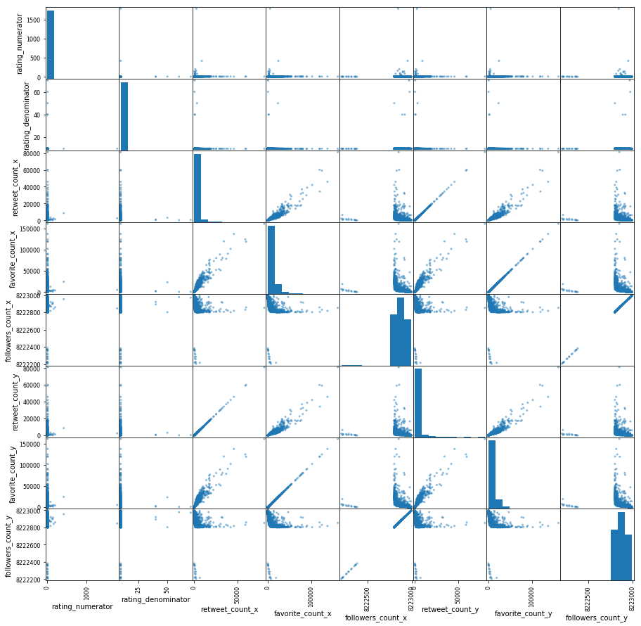

```python
pd.plotting.scatter_matrix(arc_df.iloc[:, 1:], figsize=(15, 15));
```

##### Number of tweets posted by WeRateDogs' over time

```python
arc_df['timestamp'].apply(lambda x: x.strftime('%Y-%m')).value_counts().sort_index()
```

```
2015-11    296
2015-12    367
2016-01    169
2016-02    111
2016-03    120
2016-04     54
2016-05     57
2016-06     81
2016-07     88
2016-08     59
2016-09     63
2016-10     65
2016-11     53
2016-12     54
2017-01     66
2017-02     64
2017-03     48
2017-04     41
2017-05     43
2017-06     44
2017-07     49
2017-08      2
Name: timestamp, dtype: int64
```

##### Most used Twitter source

```python
arc_df['source'].value_counts()
```

```
Twitter for iPhone    1955
Twitter Web Client      28
TweetDeck               11
Name: source, dtype: int64
```

WeRateDogs has posted 98% of the tweets from iPhone.

##### Analysis of rating of dogs

```python
arc_df['rating_numerator'].value_counts().sort_index()
```

```
0         2
1         4
2         9
3        19
4        15
5        32
6        32
7        52
8        95
9       151
10      421
11      399
12      450
13      262
14       36
```

[output cut: 16 more lines]

```python
arc_df['rating_numerator'][arc_df['rating_numerator'] > 10].value_counts().sum()
```

```
1162
```

Out of a total of 1994 dogs rated by WeRateDogs, a total of 1162 dogs were rated above 10. However, only 2%(36) were rated the highest (excluding the ratings of outliers).

```python
arc_df.name.value_counts()
```

```
Charlie     13
Oliver      11
Cooper      10
Tucker       9
Lucy         9
Penny        8
Daisy        8
Winston      8
Lola         7
Sadie        6
Stanley      6
Bella        6
Koda         6
Toby         6
Rusty        5
Dave         5
Louis        5
Buddy        5
Leo          5
Bo           5
Jax          5
Bear         5
Milo         5
Bailey       5
Sophie       5
Scout        5
Derek        4
Ruby         4
Oscar        4
Clark        4
            ..
Juckson      1
Blipson      1
Berta        1
Katie        1
Spanky       1
Kollin       1
Paul         1
Billl        1
Pulitzer     1
Jockson      1
Bobble       1
Godi         1
Seal         1
Erik         1
Horace       1
Lenox        1
Lizzie       1
Tess         1
River        1
Noah         1
Jameson      1
Clifford     1
Ridley       1
Flurp        1
Grady        1
Mingus       1
Anthony      1
Alphred      1
Stella       1
Sunshine     1
Name: name, Length: 937, dtype: int64
```

```python
arc_df.info()
```

```
<class 'pandas.core.frame.DataFrame'>
RangeIndex: 1994 entries, 0 to 1993
Data columns (total 17 columns):
tweet_id              1994 non-null object
timestamp             1994 non-null datetime64[ns, UTC]
source                1994 non-null object
text                  1994 non-null object
expanded_urls         1994 non-null object
rating_numerator      1994 non-null int64
rating_denominator    1981 non-null float64
name                  1372 non-null object
retweet_count_x       1988 non-null float64
favorite_count_x      1988 non-null float64
followers_count_x     1988 non-null float64
date                  1994 non-null object
time                  1994 non-null object
retweet_count_y       1988 non-null float64
favorite_count_y      1988 non-null float64
followers_count_y     1988 non-null float64
dog_type              326 non-null category
dtypes: category(1), datetime64[ns, UTC](1), float64(7), int64(1), object(7)
memory usage: 251.5+ KB
```

```python
arc_df.retweet_count_x.describe()
```

```
count     1988.000000
mean      2557.463783
std       4576.031178
min         11.000000
25%        572.500000
50%       1229.500000
75%       2908.000000
max      81088.000000
Name: retweet_count_x, dtype: float64
```

```python
img_df.info()
```

```
<class 'pandas.core.frame.DataFrame'>
RangeIndex: 6027 entries, 0 to 6026
Data columns (total 7 columns):
tweet_id            6027 non-null object
jpg_url             6027 non-null object
img_num             6027 non-null int64
prediction_order    6027 non-null category
prediction          6027 non-null object
confidence          6027 non-null float64
dog                 6027 non-null bool
dtypes: bool(1), category(1), float64(1), int64(1), object(3)
memory usage: 247.4+ KB
```

```python
arc_df.retweet_count_x.describe()
```

```
count     1988.000000
mean      2557.463783
std       4576.031178
min         11.000000
25%        572.500000
50%       1229.500000
75%       2908.000000
max      81088.000000
Name: retweet_count_x, dtype: float64
```

```python
arc_df.retweet_count_y.describe()
```

```
count     1988.000000
mean      2557.463783
std       4576.031178
min         11.000000
25%        572.500000
50%       1229.500000
75%       2908.000000
max      81088.000000
Name: retweet_count_y, dtype: float64
```

```python
def set_my_palette():
    sns.set()
    current_palette = sns.color_palette(my_palette)
    sns.set_palette(current_palette)
```

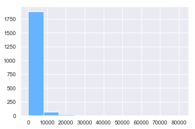

```python
my_palette = ['#66b3ff', '#00cc99', '#ff6666', '#ffff66', '#8c66ff', '#66ffd9']
set_my_palette()
arc_df.retweet_count_x.hist();
```

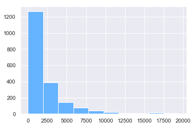

```python
arc_df[arc_df.retweet_count_x <= 20000].retweet_count_x.hist();
```

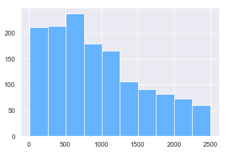

```python
arc_df[arc_df.retweet_count_x <= 2500].retweet_count_x.hist();
```

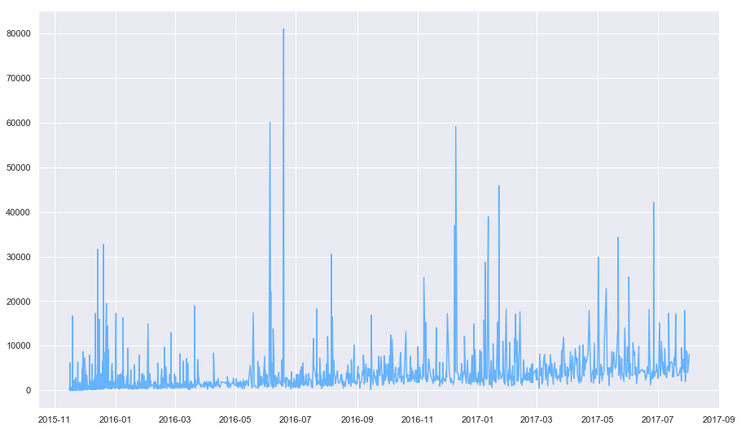

```python
sns.set_context()
plt.subplots(figsize=(15, 9))
plt.plot(arc_df.timestamp, arc_df.retweet_count_x);
```

```python
weekly_retweet = arc_df.groupby(pd.Grouper(key='timestamp', freq='1w'))['retweet_count_x'].sum()\
                    .reset_index().sort_values('timestamp')[:-1]
```

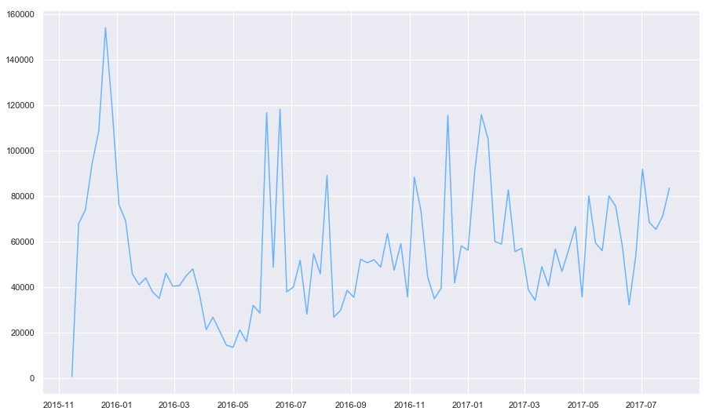

```python
plt.subplots(figsize=(15, 9))
plt.plot(weekly_retweet.timestamp, weekly_retweet.retweet_count_x);
```

```python
# Get index
ind = arc_df.retweet_count_x.nlargest(5).index
# Get details
high_retweet = arc_df[['tweet_id', 'text', 'name', 'retweet_count_x', 'favorite_count_x', 'rating_numerator', 'rating_denominator', 'dog_type']].iloc[ind]
high_retweet
```

|  | tweet_id | text | name | retweet_count_x | favorite_count_x | rating_numerator | rating_denominator | dog_type |
| --- | --- | --- | --- | --- | --- | --- | --- | --- |
| 775 | 744234799360020481 | Here's a doggo realizing you can stand in a po... | NaN | 81088.0 | 161314.0 | 13 | 10.0 | doggo |
| 810 | 739238157791694849 | Here's a doggo blowing bubbles. It's downright... | NaN | 60099.0 | 119157.0 | 13 | 10.0 | doggo |
| 400 | 807106840509214720 | This is Stephan. He just wants to help. 13/10 ... | Stephan | 59137.0 | 124645.0 | 13 | 10.0 | NaN |
| 309 | 822872901745569793 | Here's a super supportive puppo participating ... | NaN | 45904.0 | 137510.0 | 13 | 10.0 | puppo |
| 58 | 879415818425184262 | This is Duddles. He did an attempt. 13/10 some... | Duddles | 42152.0 | 102280.0 | 13 | 10.0 | NaN |

```python
high_retweet.describe()
```

|  | retweet_count_x | favorite_count_x | rating_numerator | rating_denominator |
| --- | --- | --- | --- | --- |
| count | 5.000000 | 5.000000 | 5.0 | 5.0 |
| mean | 57676.000000 | 128981.200000 | 13.0 | 10.0 |
| std | 15294.621228 | 22059.136445 | 0.0 | 0.0 |
| min | 42152.000000 | 102280.000000 | 13.0 | 10.0 |
| 25% | 45904.000000 | 119157.000000 | 13.0 | 10.0 |
| 50% | 59137.000000 | 124645.000000 | 13.0 | 10.0 |
| 75% | 60099.000000 | 137510.000000 | 13.0 | 10.0 |
| max | 81088.000000 | 161314.000000 | 13.0 | 10.0 |

### Favorite Count

```python
arc_df.favorite_count_x.describe()
```

```
count      1988.000000
mean       8524.562877
std       12537.121316
min          75.000000
25%        1834.000000
50%        3849.000000
75%       10619.250000
max      161314.000000
Name: favorite_count_x, dtype: float64
```

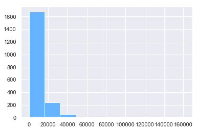

```python
arc_df.favorite_count_x.hist();
```

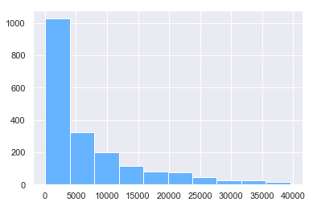

```python
arc_df[arc_df.favorite_count_x <= 40000].favorite_count_x.hist();
```

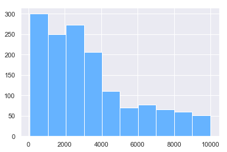

```python
arc_df[arc_df.favorite_count_x <= 10000].favorite_count_x.hist();
```

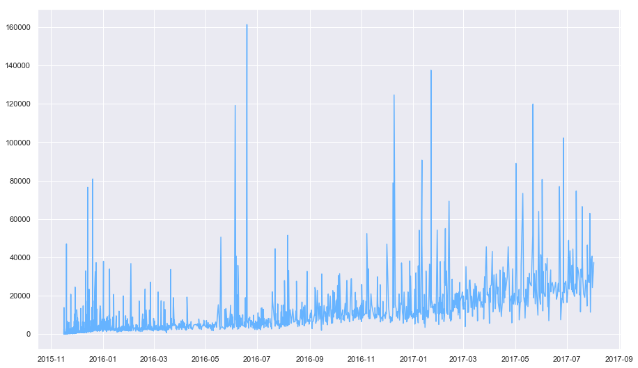

```python
plt.subplots(figsize=(15, 9))
plt.plot(arc_df.timestamp, arc_df.favorite_count_x);
```

```python
weekly_favorite = arc_df.groupby(pd.Grouper(key='timestamp', freq='1w'))['favorite_count_x'].sum()\
                    .reset_index().sort_values('timestamp')[:-1]
```

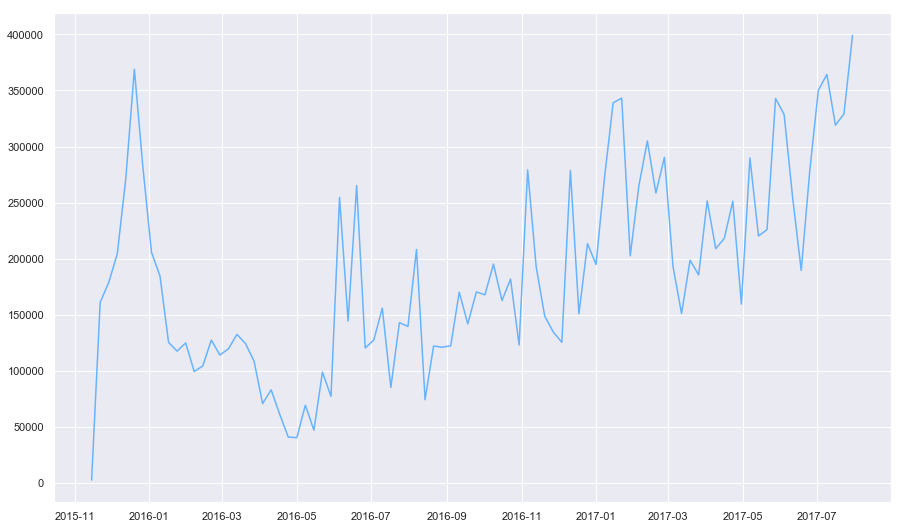

```python
plt.subplots(figsize=(15, 9))
plt.plot(weekly_favorite.timestamp, weekly_favorite.favorite_count_x);
```

### Most Popular Names

```python
arc_df.name.value_counts().head(10)
```

```
Charlie    13
Oliver     11
Cooper     10
Tucker      9
Lucy        9
Penny       8
Daisy       8
Winston     8
Lola        7
Sadie       6
Name: name, dtype: int64
```

The most popular name is Charlie.

### Over Time

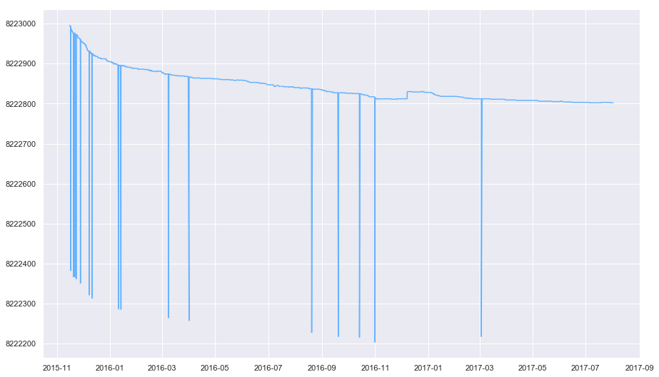

```python
plt.subplots(figsize=(15, 9))
plt.plot(arc_df.timestamp, arc_df.followers_count_x);
```

```python
arc_df.followers_count_x.describe()
```

```
count    1.988000e+03
mean     8.222874e+06
std      7.672310e+01
min      8.222204e+06
25%      8.222827e+06
50%      8.222871e+06
75%      8.222921e+06
max      8.222996e+06
Name: followers_count_x, dtype: float64
```

```python
dog_counts = arc_df.groupby('dog_type')['tweet_id'].count()
dog_counts
```

```
dog_type
doggo       66
floofer      3
pupper     229
puppo       28
Name: tweet_id, dtype: int64
```

```python
arc_df_master.describe()
```

|  | tweet_id | rating_numerator | rating_denominator | retweet_count_x | favorite_count_x | followers_count_x | retweet_count_y | favorite_count_y | followers_count_y | img_num | p1_conf | p2_conf | p3_conf | retweet_count | favorite_count | followers_count |
| --- | --- | --- | --- | --- | --- | --- | --- | --- | --- | --- | --- | --- | --- | --- | --- | --- |
| count | 1.923000e+03 | 1923.000000 | 1923.000000 | 1923.000000 | 1923.000000 | 1.923000e+03 | 1923.000000 | 1923.000000 | 1.923000e+03 | 1923.000000 | 1923.000000 | 1.923000e+03 | 1.923000e+03 | 1923.000000 | 1923.000000 | 1.923000e+03 |
| mean | 7.348426e+17 | 12.293812 | 10.551742 | 2324.654706 | 7952.659386 | 8.222875e+06 | 2324.654706 | 7952.659386 | 8.222875e+06 | 1.201768 | 0.593191 | 1.338991e-01 | 6.020538e-02 | 2324.654706 | 7952.659386 | 8.222875e+06 |
| std | 6.763808e+16 | 42.256655 | 7.453973 | 4111.853859 | 11693.583221 | 7.747455e+01 | 4111.853859 | 11693.583221 | 7.747455e+01 | 0.558593 | 0.273002 | 1.005014e-01 | 5.083562e-02 | 4111.853859 | 11693.583221 | 7.747455e+01 |
| min | 6.660209e+17 | 0.000000 | 2.000000 | 11.000000 | 75.000000 | 8.222204e+06 | 11.000000 | 75.000000 | 8.222204e+06 | 1.000000 | 0.044333 | 1.011300e-08 | 1.740170e-10 | 11.000000 | 75.000000 | 8.222204e+06 |
| 25% | 6.755330e+17 | 10.000000 | 10.000000 | 557.000000 | 1750.000000 | 8.222827e+06 | 557.000000 | 1750.000000 | 8.222827e+06 | 1.000000 | 0.359966 | 5.397835e-02 | 1.619495e-02 | 557.000000 | 1750.000000 | 8.222827e+06 |
| 50% | 7.072973e+17 | 11.000000 | 10.000000 | 1184.000000 | 3646.000000 | 8.222873e+06 | 1184.000000 | 3646.000000 | 8.222873e+06 | 1.000000 | 0.587342 | 1.164420e-01 | 4.965610e-02 | 1184.000000 | 3646.000000 | 8.222873e+06 |
| 75% | 7.859003e+17 | 12.000000 | 10.000000 | 2646.000000 | 9624.000000 | 8.222922e+06 | 2646.000000 | 9624.000000 | 8.222922e+06 | 1.000000 | 0.847827 | 1.942290e-01 | 9.153815e-02 | 2646.000000 | 9624.000000 | 8.222922e+06 |
| max | 8.924206e+17 | 1776.000000 | 170.000000 | 81088.000000 | 161314.000000 | 8.222996e+06 | 81088.000000 | 161314.000000 | 8.222996e+06 | 4.000000 | 1.000000 | 4.880140e-01 | 2.734190e-01 | 81088.000000 | 161314.000000 | 8.222996e+06 |

```python
arc_df_master.p1.value_counts()
arc_df_master.p2.value_counts()
arc_df_master.p3.value_counts()
```

```
labrador retriever                73
chihuahua                         56
golden retriever                  44
eskimo dog                        34
kelpie                            31
chow                              30
toy poodle                        29
pekinese                          28
kuvasz                            28
staffordshire bullterrier         28
beagle                            28
cocker spaniel                    27
pembroke                          25
great pyrenees                    25
malamute                          24
french bulldog                    24
pomeranian                        24
cardigan                          23
american staffordshire terrier    22
chesapeake bay retriever          20
bull mastiff                      19
siberian husky                    19
pug                               19
basenji                           19
shetland sheepdog                 17
boston bull                       17
lakeland terrier                  16
toy terrier                       16
standard poodle                   15
dingo                             15
                                  ..
wolf spider                        1
plastic bag                        1
banana                             1
canoe                              1
shovel                             1
swimming trunks                    1
rotisserie                         1
hammerhead                         1
maze                               1
balance beam                       1
soccer ball                        1
plunger                            1
screw                              1
whiptail                           1
cowboy boot                        1
shower cap                         1
shoji                              1
jeep                               1
pajama                             1
mitten                             1
maraca                             1
pretzel                            1
rhinoceros beetle                  1
nipple                             1
jersey                             1
entertainment center               1
grey fox                           1
rifle                              1
wallet                             1
notebook                           1
Name: p3, Length: 401, dtype: int64
```